# Fundamental Physical Constants

Joanh

2015

Just a bit of gymnastics on data collation, R and Knitr to display the most exact available values of the [physical constants](https://en.wikipedia.org/wiki/Physical_constant).

## Data source

**Fundamental Physical Constants — Complete Listing** from the [NIST reference on Constants, Units, and Uncertainity](https://physics.nist.gov/cuu/Constants/index.html). Via [the raw ASCII data](http://physics.nist.gov/cuu/Constants/Table/allascii.txt) edited through [Open Refine](http://openrefine.org/) to get [this csv file](https://raw.githubusercontent.com/joanh/Physical-Constants/master/Fundamental-Physical-Constants.csv), and then the few chunks of **R** code shown below.

## Code

```r
knitr::opts_chunk$set(echo = TRUE)
```

First we import the csv file from the [github repository](https://raw.githubusercontent.com/joanh/Physical-Constants/master/Fundamental-Physical-Constants.csv)

```r
GH_url <- "https://raw.githubusercontent.com/joanh/Physical-Constants/master/Fundamental-Physical-Constants.csv"
PhysicalConstants <- read.csv(GH_url, header = TRUE, sep = ",",dec = ".")
```

You can do it from your local computer after downloading the file “Fundamental-Physical-Constants.csv” through ‘[read.table](https://stat.ethz.ch/R-manual/R-devel/library/utils/html/read.table.html)’ command:

```r
# PhysicalConstants <- read.table("~/R/Physical Constants/Fundamental-Physical-Constants.csv",
# header = TRUE, sep = ",",dec = ".")
```

Then you need remove the spaces from “Value” and “Uncertainty” text columns:

```r
PhysicalConstants$Value <- str_replace_all(PhysicalConstants$Value, fixed(" "), "")
PhysicalConstants$Uncertainty <- str_replace_all(PhysicalConstants$Uncertainty, fixed(" "), "")
```

and fit the residual characters coming from exact values:

```r
PhysicalConstants$Value <- str_replace_all(PhysicalConstants$Value, fixed("..."), "")
PhysicalConstants$Uncertainty <- str_replace_all(PhysicalConstants$Uncertainty, fixed("(exact)"), "0.0")
```

You can now convert strings to numeric (scientific notation):

```r
PhysicalConstants$Value <- as.numeric(PhysicalConstants$Value)
PhysicalConstants$Uncertainty <- as.numeric(PhysicalConstants$Uncertainty)
```

## Order of magnitude histogram

Just a quick graphical test in order to check everything went right, a histogram made from the count of values of the base 10 logarithm of the absolute value of each physical constant, in other words, the exponent of the constant, i.e. its *order of magnitude*.

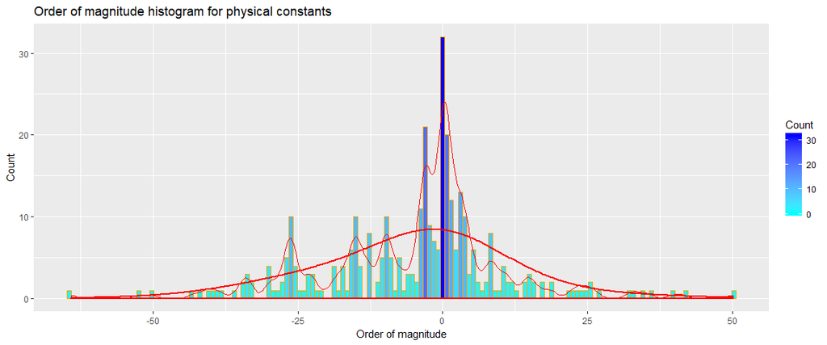

```r
histogram <- ggplot(data=PhysicalConstants, aes(log10(abs(PhysicalConstants$Value)))) +
  geom_histogram(col="orange",
                 aes(fill=..count..), binwidth= .75) +
  scale_fill_gradient("Count", low="cyan", high="blue") +
  geom_density(aes(y =..count..), colour="red", adjust=0.3, size=0.3) +
  geom_density(aes(y =..count..), colour="red", adjust=3, size=1) +
  ggtitle("Order of magnitude histogram for physical constants") +
  labs(x="Order of magnitude", y="Count")
#
# print(histogram)
```

## Table

And finally a quick table (pending to take a look to the R interface to the JavaScript library suggested [here](https://stackoverflow.com/questions/27120002/is-it-possible-to-have-sortableinteractive-table-in-rmarkdown). Start [here](http://rstudio.github.io/DT/)).

Note tha we have to setup the `digits` value because by default number is truncated to 7 decimal places (**yihui** himself explain it in [this thread](https://github.com/yihui/knitr/issues/1187)), and we can see in the above histogram we need about 70 to cover smallest constants.

```r
kable(PhysicalConstants,format = "markdown", digits = 70)
```

| Quantity | Value | Unit | Uncertainty |
| --- | --- | --- | --- |
| {220} Lattice Spacing Of Silicon | 1.920156e-10 | m | 3.2e-18 |
| Alpha Particle-electron Mass Ratio | 7.294300e+03 |  | 2.4e-07 |
| Alpha Particle Mass | 6.644657e-27 | kg | 8.2e-35 |
| Alpha Particle Mass Energy Equivalent | 5.971920e-10 | J | 7.3e-18 |
| Alpha Particle Mass Energy Equivalent In Mev | 3.727379e+03 | MeV | 2.3e-05 |
| Alpha Particle Mass In U | 4.001506e+00 | u | 6.3e-11 |
| Alpha Particle Molar Mass | 4.001506e-03 | kg mol^-1 | 6.3e-14 |
| Alpha Particle-proton Mass Ratio | 3.972600e+00 |  | 3.6e-10 |
| Angstrom Star | 1.000015e-10 | m | 9.0e-17 |
| Atomic Mass Constant | 1.660539e-27 | kg | 2.0e-35 |
| Atomic Mass Constant Energy Equivalent | 1.492418e-10 | J | 1.8e-18 |
| Atomic Mass Constant Energy Equivalent In Mev | 9.314941e+02 | MeV | 5.7e-06 |
| Atomic Mass Unit-electron Volt Relationship | 9.314941e+08 | eV | 5.7e+00 |
| Atomic Mass Unit-hartree Relationship | 3.423178e+07 | E_h | 1.6e-02 |
| Atomic Mass Unit-hertz Relationship | 2.252343e+23 | Hz | 1.0e+14 |
| Atomic Mass Unit-inverse Meter Relationship | 7.513007e+14 | m^-1 | 3.4e+05 |
| Atomic Mass Unit-joule Relationship | 1.492418e-10 | J | 1.8e-18 |
| Atomic Mass Unit-kelvin Relationship | 1.080954e+13 | K | 6.2e+06 |
| Atomic Mass Unit-kilogram Relationship | 1.660539e-27 | kg | 2.0e-35 |
| Atomic Unit Of 1st Hyperpolarizability | 3.206361e-53 | C^3 m^3 J^-2 | 2.0e-61 |
| Atomic Unit Of 2nd Hyperpolarizability | 6.235380e-65 | C^4 m^4 J^-3 | 0.0e+00 |
| Atomic Unit Of Action | 1.054572e-34 | J s | 1.3e-42 |
| Atomic Unit Of Charge | 1.602177e-19 | C | 9.8e-28 |
| Atomic Unit Of Charge Density | 1.081202e+12 | C m^-3 | 6.7e+03 |
| Atomic Unit Of Current | 6.623618e-03 | A | 4.1e-11 |
| Atomic Unit Of Electric Dipole Mom. | 8.478354e-30 | C m | 5.2e-38 |
| Atomic Unit Of Electric Field | 5.142207e+11 | V m^-1 | 3.2e+03 |
| Atomic Unit Of Electric Field Gradient | 9.717362e+21 | V m^-2 | 6.0e+13 |
| Atomic Unit Of Electric Polarizability | 1.648777e-41 | C^2 m^2 J^-1 | 1.1e-50 |
| Atomic Unit Of Electric Potential | 2.721139e+01 | V | 1.7e-07 |

[output cut: 305 more lines]